# Binary Classification Model for BNP Paribas Cardif Claims Management Using Scikit-Learn Take 1

### August 7, 2020

Template Credit: Adapted from a template made available by Dr. Jason Brownlee of Machine Learning Mastery. [https://machinelearningmastery.com/]

SUMMARY: The purpose of this project is to construct a predictive model using various machine learning algorithms and to document the end-to-end steps using a template. The BNP Paribas Cardif Claims Management dataset is a binary classification situation where we are trying to predict one of the two possible outcomes.

INTRODUCTION: As a global specialist in personal insurance, BNP Paribas Cardif sponsored a Kaggle competition to help them identify the categories of claims. In a world shaped by the emergence of new practices and behaviors generated by the digital economy, BNP Paribas Cardif would like to streamline its claims management practice. In this Kaggle challenge, the company challenged the participants to predict the category of a claim based on features available early in the process. Better predictions can help BNP Paribas Cardif accelerate its claims process and therefore provide a better service to its customers.

In this Take1 iteration, we will construct and tune several machine learning models using the Scikit-learn library. Furthermore, we will apply the best-performing machine learning model to Kaggle's test dataset and submit a list of predictions for evaluation.

CONCLUSION: For this iteration, the Random Forest model achieved the best overall results using the training and test datasets. For this dataset, we should consider further modeling with the Random Forest algorithm.

Dataset Used: BNP Paribas Cardif Claims Management Data Set

Dataset ML Model: Binary classification with numerical and categorical attributes

Dataset Reference: https://www.kaggle.com/c/bnp-paribas-cardif-claims-management/overview

One potential source of performance benchmark: https://www.kaggle.com/c/bnp-paribas-cardif-claims-management/leaderboard

Any predictive modeling machine learning project generally can be broken down into about six major tasks:

1. Prepare Environment
2. Summarize and Visualize Data
3. Prepare and Clean Data
4. Train and Evaluate Models
5. Fine-tune and Improve Models
6. Finalize Model and Present Analysis

## Task 1 - Prepare Environment

```python
# Install the necessary packages for Colab
# !pip install python-dotenv PyMySQL
```

```python
# Retrieve the GPU information from Colab
# gpu_info = !nvidia-smi
# gpu_info = '\n'.join(gpu_info)
# if gpu_info.find('failed') >= 0:
#     print('Select the Runtime → "Change runtime type" menu to enable a GPU accelerator, ')
#     print('and then re-execute this cell.')
# else:
#     print(gpu_info)
```

```python
# Retrieve the memory configuration from Colab
# from psutil import virtual_memory
# ram_gb = virtual_memory().total / 1e9
# print('Your runtime has {:.1f} gigabytes of available RAM\n'.format(ram_gb))

# if ram_gb < 20:
#     print('To enable a high-RAM runtime, select the Runtime → "Change runtime type"')
#     print('menu, and then select High-RAM in the Runtime shape dropdown. Then, ')
#     print('re-execute this cell.')
# else:
#     print('You are using a high-RAM runtime!')
```

```python
# Retrieve the CPU information
ncpu = !nproc
print("The number of available CPUs is:", ncpu[0])
```

```
The number of available CPUs is: 4
```

### 1.a) Load libraries and modules

```python
# Set the random seed number for reproducible results
seedNum = 888
```

```python
import numpy as np
import pandas as pd
import matplotlib.pyplot as plt
import os
import sys
import math
import smtplib
import boto3
from datetime import datetime
from dotenv import load_dotenv
from sklearn.compose import ColumnTransformer
from sklearn.pipeline import Pipeline
from sklearn.impute import SimpleImputer
from sklearn.preprocessing import StandardScaler
from sklearn.preprocessing import OneHotEncoder
from sklearn.model_selection import train_test_split
from sklearn.model_selection import StratifiedKFold
from sklearn.model_selection import cross_val_score
from sklearn.model_selection import GridSearchCV
from sklearn.metrics import classification_report
from sklearn.metrics import confusion_matrix
from sklearn.metrics import accuracy_score
from sklearn.metrics import roc_auc_score
from sklearn.metrics import log_loss
from sklearn.linear_model import LogisticRegression
from sklearn.ensemble import BaggingClassifier
from sklearn.ensemble import RandomForestClassifier
from sklearn.ensemble import ExtraTreesClassifier
```

### 1.b) Set up the controlling parameters and functions

```python
# Begin the timer for the script processing
startTimeScript = datetime.now()

# Set up the number of CPU cores available for multi-thread processing
n_jobs = 2

# Set up the flag to stop sending progress emails (setting to True will send status emails!)
notifyStatus = False

# Set up the parent directory location for loading the dotenv files
useColab = False
if useColab:
    # Mount Google Drive locally for storing files
    from google.colab import drive
    drive.mount('/content/gdrive')
    gdrivePrefix = '/content/gdrive/My Drive/Colab_Downloads/'
    env_path = '/content/gdrive/My Drive/Colab Notebooks/'
    dotenv_path = env_path + "python_script.env"
    load_dotenv(dotenv_path=dotenv_path)

# Set up the dotenv file for retrieving environment variables
useLocalPC = False
if useLocalPC:
    env_path = "/Users/david/PycharmProjects/"
    dotenv_path = env_path + "python_script.env"
    load_dotenv(dotenv_path=dotenv_path)

# Configure the plotting style
plt.style.use('seaborn')

# Set Pandas options
pd.set_option("display.max_rows", None)
pd.set_option("display.width", 140)

# Set the percentage sizes for splitting the dataset
# test_set_size = 0.2
val_set_size = 0.25

# Set the number of folds for cross validation
n_folds = 5

# Set various default modeling parameters
scoring = 'neg_log_loss'
```

```python
# Set up the email notification function
def status_notify(msg_text):
    access_key = os.environ.get('SNS_ACCESS_KEY')
    secret_key = os.environ.get('SNS_SECRET_KEY')
    aws_region = os.environ.get('SNS_AWS_REGION')
    topic_arn = os.environ.get('SNS_TOPIC_ARN')
    if (access_key is None) or (secret_key is None) or (aws_region is None):
        sys.exit("Incomplete notification setup info. Script Processing Aborted!!!")
    sns = boto3.client('sns', aws_access_key_id=access_key, aws_secret_access_key=secret_key, region_name=aws_region)
    response = sns.publish(TopicArn=topic_arn, Message=msg_text)
    if response['ResponseMetadata']['HTTPStatusCode'] != 200 :
        print('Status notification not OK with HTTP status code:', response['ResponseMetadata']['HTTPStatusCode'])
```

```python
if notifyStatus: status_notify("Task 1 - Prepare Environment has begun! " + datetime.now().strftime('%a %B %d, %Y %I:%M:%S %p'))
```

### 1.c) Load dataset

```python
dataset_path = 'https://dainesanalytics.com/datasets/kaggle-bnp-paribas-cardif-claims-management/train.csv'
Xy_original = pd.read_csv(dataset_path, sep=',', index_col=False)

# Take a peek at the dataframe after import
Xy_original.head(10)
```

|  | ID | target | v1 | v2 | v3 | v4 | v5 | v6 | v7 | v8 | ... | v122 | v123 | v124 | v125 | v126 | v127 | v128 | v129 | v130 | v131 |
| --- | --- | --- | --- | --- | --- | --- | --- | --- | --- | --- | --- | --- | --- | --- | --- | --- | --- | --- | --- | --- | --- |
| 0 | 3 | 1 | 1.335739 | 8.727474 | C | 3.921026 | 7.915266 | 2.599278 | 3.176895 | 0.012941 | ... | 8.000000 | 1.989780 | 0.035754 | AU | 1.804126 | 3.113719 | 2.024285 | 0 | 0.636365 | 2.857144 |
| 1 | 4 | 1 | NaN | NaN | C | NaN | 9.191265 | NaN | NaN | 2.301630 | ... | NaN | NaN | 0.598896 | AF | NaN | NaN | 1.957825 | 0 | NaN | NaN |
| 2 | 5 | 1 | 0.943877 | 5.310079 | C | 4.410969 | 5.326159 | 3.979592 | 3.928571 | 0.019645 | ... | 9.333333 | 2.477596 | 0.013452 | AE | 1.773709 | 3.922193 | 1.120468 | 2 | 0.883118 | 1.176472 |
| 3 | 6 | 1 | 0.797415 | 8.304757 | C | 4.225930 | 11.627438 | 2.097700 | 1.987549 | 0.171947 | ... | 7.018256 | 1.812795 | 0.002267 | CJ | 1.415230 | 2.954381 | 1.990847 | 1 | 1.677108 | 1.034483 |
| 4 | 8 | 1 | NaN | NaN | C | NaN | NaN | NaN | NaN | NaN | ... | NaN | NaN | NaN | Z | NaN | NaN | NaN | 0 | NaN | NaN |
| 5 | 9 | 0 | NaN | NaN | C | NaN | 8.856791 | NaN | NaN | 0.359993 | ... | NaN | NaN | 0.049861 | X | NaN | NaN | 1.536222 | 0 | NaN | NaN |
| 6 | 12 | 0 | 0.899806 | 7.312995 | C | 3.494148 | 9.946200 | 1.926070 | 1.770427 | 0.066251 | ... | 3.476299 | 1.992594 | 0.083758 | BJ | 3.276100 | 1.623298 | 2.266575 | 0 | 2.263736 | 0.970873 |
| 7 | 21 | 1 | NaN | NaN | C | NaN | NaN | NaN | NaN | NaN | ... | NaN | NaN | NaN | BY | NaN | NaN | NaN | 0 | NaN | NaN |
| 8 | 22 | 0 | 2.078651 | 8.462619 | NaN | 3.739030 | 5.265636 | 1.573033 | 2.303371 | 0.015869 | ... | 8.148148 | 1.875560 | 0.018659 | S | 1.159637 | 5.582865 | 1.105283 | 0 | 1.170731 | 3.333334 |
| 9 | 23 | 1 | 1.144802 | 5.880606 | C | 3.244469 | 9.538384 | 2.500001 | 1.559405 | 0.412610 | ... | 7.325843 | 4.896617 | 0.008944 | E | 1.344550 | 1.601176 | 1.928009 | 0 | 3.174603 | 1.000000 |

10 rows × 133 columns

```python
Xy_original.info(verbose=True)
```

```
<class 'pandas.core.frame.DataFrame'>
RangeIndex: 114321 entries, 0 to 114320
Data columns (total 133 columns):
 #   Column  Dtype
---  ------  -----
 0   ID      int64
 1   target  int64
 2   v1      float64
 3   v2      float64
 4   v3      object
 5   v4      float64
 6   v5      float64
 7   v6      float64
 8   v7      float64
 9   v8      float64
```

[output cut: 125 more lines]

### 1.d) Splitting Data into Training/Validation/Test Sets

```python
# Drop the ID or index column not used for modeling
Xy_original.drop(columns=['ID'], inplace=True)

# Use variable totCol to hold the number of columns in the dataframe
totCol = len(Xy_original.columns)

# Set up variable totAttr for the total number of attribute columns
totAttr = totCol-1

# targetCol variable indicates the column location of the target/class variable
# If the first column, set targetCol to 1. If the last column, set targetCol to totCol
# If (targetCol <> 1) and (targetCol <> totCol), be aware when slicing up the dataframes for visualization
targetCol = 1
```

```python
# We create attribute-only and target-only datasets (X_original and y_original)
# for various visualization and cleaning/transformation operations

if targetCol == totCol:
    X_original = Xy_original.iloc[:,0:totAttr]
    y_original = Xy_original.iloc[:,totAttr]
else:
    X_original = Xy_original.iloc[:,1:totCol]
    y_original = Xy_original.iloc[:,0]

print("Xy_original.shape: {} X_original.shape: {} y_original.shape: {}".format(Xy_original.shape, X_original.shape, y_original.shape))
```

```
Xy_original.shape: (114321, 132) X_original.shape: (114321, 131) y_original.shape: (114321,)
```

```python
# Split the data further into smaller datasets
X_train_df, X_validation_df, y_train_df, y_validation_df = train_test_split(X_original, y_original, test_size=val_set_size, stratify=y_original, random_state=seedNum)
print("X_train_df.shape: {} y_train_df.shape: {}".format(X_train_df.shape, y_train_df.shape))
print("X_validation_df.shape: {} y_validation_df.shape: {}".format(X_validation_df.shape, y_validation_df.shape))
```

```
X_train_df.shape: (85740, 131) y_train_df.shape: (85740,)
X_validation_df.shape: (28581, 131) y_validation_df.shape: (28581,)
```

### 1.e) Set up the parameters for data visualization

```python
# Set up the number of row and columns for visualization display. dispRow * dispCol should be >= totAttr
dispCol = 4
if totAttr % dispCol == 0 :
    dispRow = totAttr // dispCol
else :
    dispRow = (totAttr // dispCol) + 1

# Set figure width to display the data visualization plots
fig_size = plt.rcParams["figure.figsize"]
fig_size[0] = dispCol*4
fig_size[1] = dispRow*4
plt.rcParams["figure.figsize"] = fig_size
```

```python
if notifyStatus: status_notify("Task 1 - Prepare Environment completed! "+datetime.now().strftime('%a %B %d, %Y %I:%M:%S %p'))
```

## Task 2 - Summarize and Visualize Data

```python
if notifyStatus: status_notify("Task 2 - Summarize and Visualize Data has begun! "+datetime.now().strftime('%a %B %d, %Y %I:%M:%S %p'))
```

### 2.a) Descriptive Statistics

#### 2.a.i) Peek at the attribute columns

```python
X_train_df.head(10)
```

|  | v1 | v2 | v3 | v4 | v5 | v6 | v7 | v8 | v9 | v10 | ... | v122 | v123 | v124 | v125 | v126 | v127 | v128 | v129 | v130 | v131 |
| --- | --- | --- | --- | --- | --- | --- | --- | --- | --- | --- | --- | --- | --- | --- | --- | --- | --- | --- | --- | --- | --- |
| 72729 | 2.501891e-07 | 9.825911 | C | 5.231909 | 9.769272 | 2.308403 | 2.197599 | 1.450759 | 9.632652 | 1.312911 | ... | 8.816327 | 1.414677 | 1.404986 | L | 1.063325 | 5.470914 | 2.526560 | 0 | 1.159664 | -3.711267e-07 |
| 63077 | 2.038942e+00 | 7.202753 | C | 4.510721 | 9.057249 | 2.689199 | 2.138133 | 2.422964 | 10.123457 | 1.575492 | ... | 7.932098 | 2.586637 | 1.112611 | J | 2.059444 | 4.808046 | 2.065386 | 0 | 2.776633 | 1.485149e+00 |
| 18397 | 4.811450e-01 | 8.154912 | C | 5.131863 | 8.682855 | 2.431729 | 1.657998 | 8.625817 | 5.284974 | 1.859956 | ... | 4.378238 | 2.199685 | 3.197708 | CE | 2.373403 | 4.608258 | 1.932607 | 0 | 2.101960 | 5.970149e-01 |
| 107232 | 5.698150e-01 | 4.747883 | C | 2.660194 | 8.451288 | 1.581109 | 2.289527 | 0.501510 | 8.118081 | 1.312911 | ... | 5.313653 | 6.929852 | 0.160894 | BM | 1.784636 | 2.252311 | 1.420580 | 0 | 2.349776 | 4.580151e-01 |
| 10477 | NaN | NaN | C | NaN | NaN | NaN | NaN | NaN | NaN | 1.291028 | ... | NaN | NaN | NaN | AZ | NaN | NaN | NaN | 0 | NaN | NaN |
| 77299 | 4.009852e+00 | 2.623027 | C | 2.494071 | 8.225611 | 1.871922 | 1.931034 | 1.507072 | 13.868194 | 2.341358 | ... | 11.174786 | 3.939930 | 0.327944 | AK | 2.087167 | 2.715518 | 1.577741 | 0 | 3.795917 | 2.365592e+00 |
| 101067 | NaN | NaN | C | NaN | 9.150284 | NaN | NaN | 0.255377 | NaN | 1.050327 | ... | NaN | NaN | 0.102788 | CA | NaN | NaN | 1.675550 | 0 | NaN | NaN |
| 98304 | NaN | NaN | C | NaN | 7.634282 | NaN | NaN | 0.271786 | NaN | 0.765864 | ... | NaN | NaN | 0.084586 | CC | NaN | NaN | 1.245167 | 0 | NaN | NaN |
| 61824 | 1.661520e+00 | 6.302897 | C | 4.045457 | 7.736621 | 2.301432 | 2.413697 | 2.536977 | 10.182926 | 0.765865 | ... | 8.475610 | 2.410540 | 0.127316 | E | 2.006312 | 2.557536 | 1.292677 | 0 | 1.739535 | 1.711230e+00 |
| 114061 | 1.509731e+00 | 7.173419 | C | 6.170578 | 9.378742 | 2.623981 | 4.375392 | 2.429126 | 7.315635 | 1.291029 | ... | 4.424779 | 2.113774 | 2.205573 | CG | 2.332378 | 2.518833 | 2.399631 | 0 | 0.734577 | 2.031250e+00 |

10 rows × 131 columns

#### 2.a.ii) Dimensions and attribute types

```python
X_train_df.info(verbose=True)
```

```
<class 'pandas.core.frame.DataFrame'>
Int64Index: 85740 entries, 72729 to 73581
Data columns (total 131 columns):
 #   Column  Dtype
---  ------  -----
 0   v1      float64
 1   v2      float64
 2   v3      object
 3   v4      float64
 4   v5      float64
 5   v6      float64
 6   v7      float64
 7   v8      float64
 8   v9      float64
 9   v10     float64
```

[output cut: 123 more lines]

#### 2.a.iii) Statistical summary of the attributes

```python
X_train_df.describe()
```

|  | v1 | v2 | v4 | v5 | v6 | v7 | v8 | v9 | v10 | v11 | ... | v121 | v122 | v123 | v124 | v126 | v127 | v128 | v129 | v130 | v131 |
| --- | --- | --- | --- | --- | --- | --- | --- | --- | --- | --- | --- | --- | --- | --- | --- | --- | --- | --- | --- | --- | --- |
| count | 4.850000e+04 | 4.852600e+04 | 4.852600e+04 | 4.940800e+04 | 4.850000e+04 | 4.850000e+04 | 4.941200e+04 | 4.848700e+04 | 8.567900e+04 | 4.849600e+04 | ... | 4.849500e+04 | 4.848700e+04 | 47868.000000 | 4.941200e+04 | 4.850000e+04 | 4.850000e+04 | 4.940800e+04 | 85740.000000 | 4.849400e+04 | 4.845900e+04 |
| mean | 1.629610e+00 | 7.455411e+00 | 4.145609e+00 | 8.735930e+00 | 2.438247e+00 | 2.482910e+00 | 1.497857e+00 | 9.035824e+00 | 1.883491e+00 | 1.544844e+01 | ... | 2.737478e+00 | 6.823857e+00 | 3.542958 | 9.205091e-01 | 1.672165e+00 | 3.247758e+00 | 2.026497e+00 | 0.310753 | 1.925066e+00 | 1.738178e+00 |
| std | 1.080319e+00 | 2.948519e+00 | 1.143439e+00 | 2.041854e+00 | 5.929179e-01 | 5.837708e-01 | 2.787460e+00 | 1.926138e+00 | 1.392860e+00 | 7.804447e-01 | ... | 1.355712e+00 | 1.789906e+00 | 2.595670 | 2.102663e+00 | 4.891719e-01 | 1.633572e+00 | 1.072913e+00 | 0.691401 | 1.260120e+00 | 1.131693e+00 |
| min | -9.996497e-07 | -8.757841e-07 | -6.475929e-07 | -5.287068e-07 | -9.055091e-07 | -9.291187e-07 | -4.233768e-07 | -9.828757e-07 | -9.875317e-07 | -1.358144e-07 | ... | -9.820642e-07 | -9.872804e-07 | 0.019139 | -9.994953e-07 | -6.649638e-07 | -9.223798e-07 | 8.197812e-07 | 0.000000 | -9.766689e-07 | -9.999134e-07 |
| 25% | 9.128051e-01 | 5.323340e+00 | 3.489761e+00 | 7.599192e+00 | 2.067183e+00 | 2.100457e+00 | 8.643555e-02 | 7.857143e+00 | 1.050328e+00 | 1.500457e+01 | ... | 1.789916e+00 | 5.648147e+00 | 1.964286 | 2.050082e-02 | 1.419244e+00 | 2.103240e+00 | 1.389093e+00 | 0.000000 | 1.108179e+00 | 1.012281e+00 |
| 50% | 1.464153e+00 | 7.013922e+00 | 4.205905e+00 | 8.659658e+00 | 2.413408e+00 | 2.451084e+00 | 3.858012e-01 | 9.060403e+00 | 1.312910e+00 | 1.549407e+01 | ... | 2.435174e+00 | 6.752689e+00 | 2.737925 | 1.393936e-01 | 1.614914e+00 | 2.968683e+00 | 1.798434e+00 | 0.000000 | 1.558974e+00 | 1.587302e+00 |
| 75% | 2.133794e+00 | 9.440600e+00 | 4.831556e+00 | 9.768831e+00 | 2.776786e+00 | 2.832898e+00 | 1.625247e+00 | 1.023924e+01 | 2.100657e+00 | 1.594937e+01 | ... | 3.379061e+00 | 7.909090e+00 | 4.067369 | 8.718332e-01 | 1.843713e+00 | 4.119718e+00 | 2.383469e+00 | 0.000000 | 2.335017e+00 | 2.261904e+00 |
| max | 2.000000e+01 | 2.000000e+01 | 1.183178e+01 | 2.000000e+01 | 2.000000e+01 | 8.888889e+00 | 2.000000e+01 | 2.000000e+01 | 1.853392e+01 | 2.000000e+01 | ... | 2.000000e+01 | 2.000000e+01 | 19.686069 | 2.000000e+01 | 1.388344e+01 | 2.000000e+01 | 1.305259e+01 | 11.000000 | 2.000000e+01 | 2.000000e+01 |

8 rows × 112 columns

#### 2.a.iv) Find Attributes with Missing Values

```python
X_train_df.isnull().sum()
```

```
v1      37240
v2      37214
v3       2608
v4      37214
v5      36332
v6      37240
v7      37240
v8      36328
v9      37253
v10        61
v11     37244
v12        63
v13     37240
v14         3
v15     37244
v16     37281
v17     37214
v18     37240
v19     37246
v20     37245
v21       464
v22       374
v23     37870
v24         0
v25     36328
v26     37240
v27     37240
v28     37240
v29     37240
v30     44994
v31      2608
v32     37240
v33     37240
v34        81
v35     37240
v36     36332
v37     37246
v38         0
v39     37244
v40        81
```

[output cut: 77 more lines]

```
v118    37246
v119    37874
v120    37244
v121    37245
v122    37253
v123    37872
v124    36328
v125       53
v126    37240
v127    37240
v128    36332
v129        0
v130    37246
v131    37281
dtype: int64
```

```python
print('Total number of NaN in the dataframe: ', X_train_df.isnull().sum().sum())
```

```
Total number of NaN in the dataframe:  3809526
```

#### 2.a.v) Summarize the levels of the class attribute

```python
y_train_df.groupby(y_train_df).size()
```

```
target
0    20475
1    65265
Name: target, dtype: int64
```

### 2.b) Data Visualization

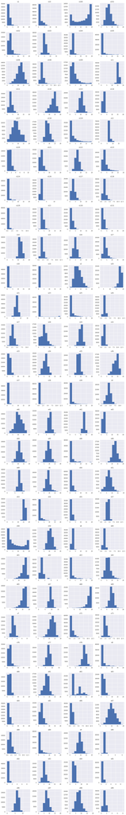

```python
# Histograms for each attribute
X_train_df.hist(layout=(dispRow,dispCol))
plt.show()
```

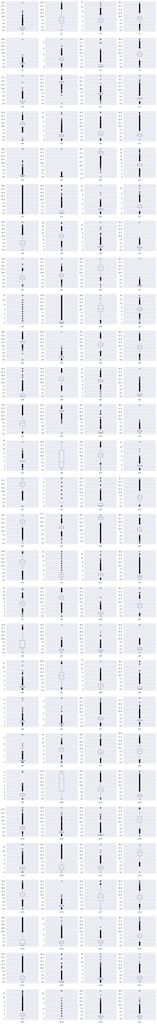

```python
# Box and Whisker plot for each attribute
X_train_df.plot(kind='box', subplots=True, layout=(dispRow,dispCol))
plt.show()
```

```python
# Correlation matrix
# fig = plt.figure(figsize=(16,12))
# ax = fig.add_subplot(111)
# correlations = X_train_df.corr(method='pearson')
# cax = ax.matshow(correlations, vmin=-1, vmax=1)
# fig.colorbar(cax)
# plt.show()
```

```python
if notifyStatus: status_notify("Task 2 - Summarize and Visualize Data completed! "+datetime.now().strftime('%a %B %d, %Y %I:%M:%S %p'))
```

## Task 3 - Prepare and Clean Data

```python
if notifyStatus: status_notify("Task 3 - Prepare and Clean Data has begun! "+datetime.now().strftime('%a %B %d, %Y %I:%M:%S %p'))
```

### 3.a) Build Data-Prep Pipeline

```python
# Dropping columns with very low or no predictive power
X_train_df.drop(columns=['v22'], inplace=True)
```

```python
# Compose pipeline for the numerical and categorical features
numeric_columns = X_train_df.select_dtypes(include=['int64','float64']).columns
numeric_transformer = Pipeline(steps=[
    ('imputer', SimpleImputer(strategy='constant', fill_value=0)),
    ('scaler', StandardScaler())
])
categorical_columns = X_train_df.select_dtypes(include=['object','bool']).columns
categorical_transformer = Pipeline(steps=[
    ('imputer', SimpleImputer(strategy='constant', fill_value='NA')),
    ('onehot', OneHotEncoder(sparse=False, handle_unknown='ignore'))
])

print("Number of numerical columns:", len(numeric_columns))
print("Number of categorical columns:", len(categorical_columns))
print("Total number of columns in the dataframe:", X_train_df.shape[1])
```

```
Number of numerical columns: 112
Number of categorical columns: 18
Total number of columns in the dataframe: 130
```

```python
preprocessor = ColumnTransformer(transformers=[
    ('num', numeric_transformer, numeric_columns),
    ('cat', categorical_transformer, categorical_columns)
])

# Display the shapes of the training datasets for final inspection
X_train = preprocessor.fit_transform(X_train_df)
y_train = y_train_df.ravel()
print("X_train.shape: {} y_train.shape: {}".format(X_train.shape, y_train.shape))
```

```
X_train.shape: (85740, 483) y_train.shape: (85740,)
```

```python
if notifyStatus: status_notify("Task 3 - Prepare and Clean Data completed! "+datetime.now().strftime('%a %B %d, %Y %I:%M:%S %p'))
```

## Task 4 - Train and Evaluate Models

```python
if notifyStatus: status_notify("Task 4 - Train and Evaluate Models has begun! "+datetime.now().strftime('%a %B %d, %Y %I:%M:%S %p'))
```

### 4.a) Set test options and evaluation metric

```python
# Set up Algorithms Spot-Checking Array
startTimeTraining = datetime.now()
train_models = []
train_results = []
train_model_names = []
train_metrics = []
train_models.append(('LGR', LogisticRegression(random_state=seedNum, max_iter=500)))
train_models.append(('BGT', BaggingClassifier(random_state=seedNum, n_jobs=n_jobs)))
train_models.append(('RNF', RandomForestClassifier(random_state=seedNum, n_jobs=n_jobs)))
train_models.append(('EXT', ExtraTreesClassifier(random_state=seedNum, n_jobs=n_jobs)))
```

```python
# Generate model in turn
for name, model in train_models:
	if notifyStatus: status_notify("Algorithm "+name+" modeling has begun! "+datetime.now().strftime('%a %B %d, %Y %I:%M:%S %p'))
	startTimeModule = datetime.now()
	kfold = StratifiedKFold(n_splits=n_folds, shuffle=True, random_state=seedNum)
	cv_results = cross_val_score(model, X_train, y_train, cv=kfold, scoring=scoring, n_jobs=n_jobs, verbose=1)
	train_results.append(cv_results)
	train_model_names.append(name)
	train_metrics.append(cv_results.mean())
	print("%s: %f (%f)" % (name, cv_results.mean(), cv_results.std()))
	print(model)
	print ('Model training time:', (datetime.now() - startTimeModule), '\n')
	if notifyStatus: status_notify("Algorithm "+name+" modeling completed! "+datetime.now().strftime('%a %B %d, %Y %I:%M:%S %p'))
print ('Average metrics ('+scoring+') from all models:',np.mean(train_metrics))
print ('Total training time for all models:',(datetime.now() - startTimeTraining))
```

```
[Parallel(n_jobs=2)]: Using backend LokyBackend with 2 concurrent workers.
[Parallel(n_jobs=2)]: Done   5 out of   5 | elapsed:  1.3min finished
[Parallel(n_jobs=2)]: Using backend LokyBackend with 2 concurrent workers.
```

```
LGR: -0.484097 (0.002572)
LogisticRegression(max_iter=500, random_state=888)
Model training time: 0:01:17.955106
```

```
[Parallel(n_jobs=2)]: Done   5 out of   5 | elapsed:  6.6min finished
[Parallel(n_jobs=2)]: Using backend LokyBackend with 2 concurrent workers.
```

```
BGT: -1.121188 (0.035909)
BaggingClassifier(n_jobs=2, random_state=888)
Model training time: 0:06:35.588205
```

```
[Parallel(n_jobs=2)]: Done   5 out of   5 | elapsed:  3.5min finished
[Parallel(n_jobs=2)]: Using backend LokyBackend with 2 concurrent workers.
```

```
RNF: -0.478283 (0.002397)
RandomForestClassifier(n_jobs=2, random_state=888)
Model training time: 0:03:31.906104

EXT: -0.485482 (0.002223)
ExtraTreesClassifier(n_jobs=2, random_state=888)
Model training time: 0:02:54.248393

Average metrics (neg_log_loss) from all models: -0.6422624813044819
Total training time for all models: 0:14:19.838305
```

```
[Parallel(n_jobs=2)]: Done   5 out of   5 | elapsed:  2.9min finished
```

### 4.b) Spot-checking baseline algorithms

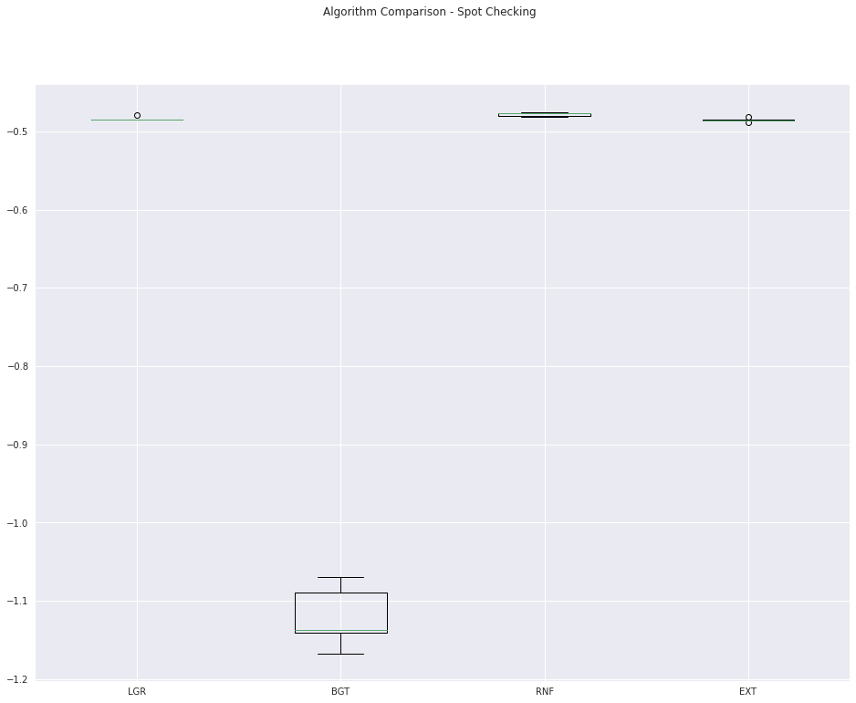

```python
fig = plt.figure(figsize=(16,12))
fig.suptitle('Algorithm Comparison - Spot Checking')
ax = fig.add_subplot(111)
plt.boxplot(train_results)
ax.set_xticklabels(train_model_names)
plt.show()
```

```python
if notifyStatus: status_notify("Task 4 - Train and Evaluate Models completed! "+datetime.now().strftime('%a %B %d, %Y %I:%M:%S %p'))
```

## Task 5 - Fine-tune and Improve Models

```python
if notifyStatus: status_notify("Task 5 - Fine-tune and Improve Models has begun! "+datetime.now().strftime('%a %B %d, %Y %I:%M:%S %p'))
```

### 5.a) Algorithm Tuning

```python
# Set up the comparison array
tune_results = []
tune_model_names = []
```

```python
# Tuning algorithm #1 - Logistic Regression
startTimeModule = datetime.now()
if notifyStatus: status_notify("Algorithm #1 tuning has begun! "+datetime.now().strftime('%a %B %d, %Y %I:%M:%S %p'))

tune_model1 = LogisticRegression(random_state=seedNum, max_iter=500)
tune_model_names.append('LGR')
paramGrid1 = dict(solver=['newton-cg','lbfgs','sag','saga'])

kfold = StratifiedKFold(n_splits=n_folds, shuffle=True, random_state=seedNum)
grid1 = GridSearchCV(estimator=tune_model1, param_grid=paramGrid1, scoring=scoring, cv=kfold, n_jobs=n_jobs, verbose=1)
grid_result1 = grid1.fit(X_train, y_train)

print("Best: %f using %s" % (grid_result1.best_score_, grid_result1.best_params_))
tune_results.append(grid_result1.cv_results_['mean_test_score'])
means = grid_result1.cv_results_['mean_test_score']
stds = grid_result1.cv_results_['std_test_score']
params = grid_result1.cv_results_['params']
for mean, stdev, param in zip(means, stds, params):
    print("%f (%f) with: %r" % (mean, stdev, param))
print ('Model training time:',(datetime.now() - startTimeModule))
if notifyStatus: status_notify("Algorithm #1 tuning completed! "+datetime.now().strftime('%a %B %d, %Y %I:%M:%S %p'))
```

```
Fitting 5 folds for each of 4 candidates, totalling 20 fits
```

```
[Parallel(n_jobs=2)]: Using backend LokyBackend with 2 concurrent workers.
[Parallel(n_jobs=2)]: Done  20 out of  20 | elapsed: 42.3min finished
```

```
Best: -0.484011 using {'solver': 'saga'}
-0.484097 (0.002588) with: {'solver': 'newton-cg'}
-0.484097 (0.002572) with: {'solver': 'lbfgs'}
-0.484021 (0.002488) with: {'solver': 'sag'}
-0.484011 (0.002449) with: {'solver': 'saga'}
Model training time: 0:51:53.287447
```

```python
best_paramKey1 = list(grid_result1.best_params_.keys())[0]
best_paramValue1 = list(grid_result1.best_params_.values())[0]
print("Captured the best parameter for algorithm #1:", best_paramKey1, '=', best_paramValue1)
```

```
Captured the best parameter for algorithm #1: solver = saga
```

```python
# Tuning algorithm #2 - Random Forest
startTimeModule = datetime.now()
if notifyStatus: status_notify("Algorithm #2 tuning has begun! "+datetime.now().strftime('%a %B %d, %Y %I:%M:%S %p'))

tune_model2 = RandomForestClassifier(random_state=seedNum, n_jobs=n_jobs)
tune_model_names.append('RNF')
paramGrid2 = dict(n_estimators=np.array([100, 200, 300, 400, 500]))

kfold = StratifiedKFold(n_splits=n_folds, shuffle=True, random_state=seedNum)
grid2 = GridSearchCV(estimator=tune_model2, param_grid=paramGrid2, scoring=scoring, cv=kfold, n_jobs=n_jobs, verbose=1)
grid_result2 = grid2.fit(X_train, y_train)

print("Best: %f using %s" % (grid_result2.best_score_, grid_result2.best_params_))
tune_results.append(grid_result2.cv_results_['mean_test_score'])
means = grid_result2.cv_results_['mean_test_score']
stds = grid_result2.cv_results_['std_test_score']
params = grid_result2.cv_results_['params']
for mean, stdev, param in zip(means, stds, params):
    print("%f (%f) with: %r" % (mean, stdev, param))
print ('Model training time:',(datetime.now() - startTimeModule))
if notifyStatus: status_notify("Algorithm #2 tuning completed! "+datetime.now().strftime('%a %B %d, %Y %I:%M:%S %p'))
```

```
Fitting 5 folds for each of 5 candidates, totalling 25 fits
```

```
[Parallel(n_jobs=2)]: Using backend LokyBackend with 2 concurrent workers.
[Parallel(n_jobs=2)]: Done  25 out of  25 | elapsed: 46.5min finished
```

```
Best: -0.472212 using {'n_estimators': 500}
-0.478283 (0.002397) with: {'n_estimators': 100}
-0.473989 (0.001152) with: {'n_estimators': 200}
-0.473303 (0.001001) with: {'n_estimators': 300}
-0.472478 (0.000594) with: {'n_estimators': 400}
-0.472212 (0.000465) with: {'n_estimators': 500}
Model training time: 0:53:35.243423
```

```python
best_paramKey2 = list(grid_result2.best_params_.keys())[0]
best_paramValue2 = list(grid_result2.best_params_.values())[0]
print("Captured the best parameter for algorithm #2:", best_paramKey2, '=', best_paramValue2)
```

```
Captured the best parameter for algorithm #2: n_estimators = 500
```

### 5.b) Compare Algorithms After Tuning

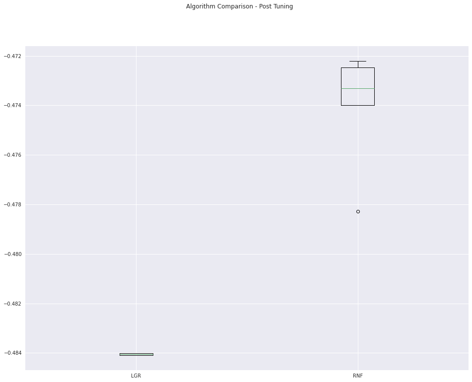

```python
fig = plt.figure(figsize=(16,12))
fig.suptitle('Algorithm Comparison - Post Tuning')
ax = fig.add_subplot(111)
plt.boxplot(tune_results)
ax.set_xticklabels(tune_model_names)
plt.show()
```

```python
if notifyStatus: status_notify("Task 5 - Fine-tune and Improve Models completed! "+datetime.now().strftime('%a %B %d, %Y %I:%M:%S %p'))
```

## Task 6 - Finalize Model and Present Analysis

```python
if notifyStatus: status_notify("Task 6 - Finalize Model and Present Analysis has begun! "+datetime.now().strftime('%a %B %d, %Y %I:%M:%S %p'))
```

### 6.a) Measure predictions from the validation dataset

```python
# Apply the same data preparation steps to the validation dataset
# Dropping columns with very low or no predictive power
X_validation_df.drop(columns=['v22'], inplace=True)

# Display the shapes of the training datasets for final inspection
X_validation = preprocessor.transform(X_validation_df)
y_validation = y_validation_df.ravel()
print("X_validation.shape: {} y_validation.shape: {}".format(X_validation.shape, y_validation.shape))
```

```
X_validation.shape: (28581, 483) y_validation.shape: (28581,)
```

```python
validation_model1 = LogisticRegression(solver=best_paramValue1, random_state=seedNum, max_iter=500)
validation_model1.fit(X_train, y_train)
predictions1 = validation_model1.predict(X_validation)
probabilities1 = validation_model1.predict_proba(X_validation)[:,1]
print('Accuracy Score:', accuracy_score(y_validation, predictions1))
print('ROC/AUC Score:', roc_auc_score(y_validation, probabilities1))
print('Logistic/Cross-Entropy Loss:', log_loss(y_validation, probabilities1))
print(confusion_matrix(y_validation, predictions1))
print(classification_report(y_validation, predictions1))
print(validation_model1)
```

```
Accuracy Score: 0.7733459291137469
ROC/AUC Score: 0.7360558091170336
Logistic/Cross-Entropy Loss: 0.4832444178890745
[[ 1114  5711]
 [  767 20989]]
              precision    recall  f1-score   support

           0       0.59      0.16      0.26      6825
           1       0.79      0.96      0.87     21756

    accuracy                           0.77     28581
   macro avg       0.69      0.56      0.56     28581
weighted avg       0.74      0.77      0.72     28581

LogisticRegression(max_iter=500, random_state=888, solver='saga')
```

```python
validation_model2 = RandomForestClassifier(n_estimators=best_paramValue2, random_state=seedNum, n_jobs=n_jobs)
validation_model2.fit(X_train, y_train)
predictions2 = validation_model2.predict(X_validation)
probabilities2 = validation_model2.predict_proba(X_validation)[:,1]
print('Accuracy Score:', accuracy_score(y_validation, predictions2))
print('ROC/AUC Score:', roc_auc_score(y_validation, probabilities2))
print('Logistic/Cross-Entropy Loss:', log_loss(y_validation, probabilities2))
print(confusion_matrix(y_validation, predictions2))
print(classification_report(y_validation, predictions2))
print(validation_model2)
```

```
Accuracy Score: 0.7822679402400196
ROC/AUC Score: 0.7566009629274936
Logistic/Cross-Entropy Loss: 0.4706302545110198
[[ 1194  5631]
 [  592 21164]]
              precision    recall  f1-score   support

           0       0.67      0.17      0.28      6825
           1       0.79      0.97      0.87     21756

    accuracy                           0.78     28581
   macro avg       0.73      0.57      0.57     28581
weighted avg       0.76      0.78      0.73     28581

RandomForestClassifier(n_estimators=500, n_jobs=2, random_state=888)
```

### 6.b) Create a standalone model using all available data

```python
# Apply the same data preparation steps to the original training dataset

# Dropping columns with very low or no predictive power
X_original.drop(columns=['v22'], inplace=True)

# Display the shapes of the training datasets for final inspection
X_complete = preprocessor.fit_transform(X_original)
y_complete = y_original.ravel()
print("X_complete.shape: {} y_complete.shape: {}".format(X_complete.shape, y_complete.shape))
final_model = validation_model2.fit(X_complete, y_complete)
print(final_model)
```

```
X_complete.shape: (114321, 486) y_complete.shape: (114321,)
RandomForestClassifier(n_estimators=500, n_jobs=2, random_state=888)
```

### 6.c) Create Submission Files for Kaggle Evaluation

```python
dataset_path = 'https://dainesanalytics.com/datasets/kaggle-bnp-paribas-cardif-claims-management/test.csv'
X_kaggle_data = pd.read_csv(dataset_path, sep=',', index_col=False)

# Take a peek at the dataframe after import
X_kaggle_data.head(10)
```

|  | ID | v1 | v2 | v3 | v4 | v5 | v6 | v7 | v8 | v9 | ... | v122 | v123 | v124 | v125 | v126 | v127 | v128 | v129 | v130 | v131 |
| --- | --- | --- | --- | --- | --- | --- | --- | --- | --- | --- | --- | --- | --- | --- | --- | --- | --- | --- | --- | --- | --- |
| 0 | 0 | 1.375465e+00 | 11.361141 | C | 4.200778 | 6.577000 | 2.081784 | 1.784386 | 0.011094 | 9.523810 | ... | 7.619048 | 1.815241 | 1.112270e-07 | AF | 1.292368 | 3.903345 | 1.485925 | 0 | 2.333334 | 1.428572e+00 |
| 1 | 1 | NaN | NaN | C | NaN | NaN | NaN | NaN | NaN | NaN | ... | NaN | NaN | NaN | I | NaN | NaN | NaN | 0 | NaN | NaN |
| 2 | 2 | -4.903407e-07 | 8.201529 | C | 4.544371 | 6.550100 | 1.558442 | 2.467532 | 0.007164 | 7.142858 | ... | 5.714286 | 1.970928 | 1.412265e-02 | AV | 1.128724 | 5.844156 | 1.475892 | 0 | 1.263157 | -6.380022e-07 |
| 3 | 7 | 2.661870e+00 | 3.041241 | C | 1.657216 | 9.773080 | 2.078337 | 1.430855 | 1.252157 | 7.959596 | ... | 4.404040 | 8.163614 | 1.100329e+00 | B | 1.988688 | 1.558753 | 2.448814 | 0 | 5.385474 | 1.493777e+00 |
| 4 | 10 | 1.252822e+00 | 11.283352 | C | 4.638388 | 8.520510 | 2.302484 | 3.510159 | 0.074263 | 7.612904 | ... | 6.580644 | 1.325654 | 2.584588e-01 | A | 1.863796 | 2.666478 | 2.374275 | 0 | 0.681672 | 2.264151e+00 |
| 5 | 11 | 1.733601e+00 | 7.525109 | C | 3.263905 | 5.608608 | 2.356090 | 2.369477 | 0.065481 | 9.935483 | ... | 5.032257 | 2.551374 | -9.391195e-07 | BM | 1.541607 | 3.463855 | 1.196959 | 0 | 2.598869 | 1.217392e+00 |
| 6 | 13 | NaN | NaN | C | NaN | NaN | NaN | NaN | NaN | NaN | ... | NaN | NaN | NaN | CK | NaN | NaN | NaN | 0 | NaN | NaN |
| 7 | 14 | 2.027902e+00 | 6.947583 | C | 5.840414 | 7.944518 | 3.607374 | 2.541107 | 1.870223 | 9.818181 | ... | 8.218182 | 2.011008 | 6.788057e-01 | BJ | 1.591433 | 2.541105 | 1.386445 | 0 | 1.129412 | 3.055555e+00 |
| 8 | 15 | 1.296225e+00 | 9.573390 | C | 3.387392 | 9.316076 | 2.133125 | 1.650447 | 0.236811 | 12.050474 | ... | 10.977917 | 2.984337 | 4.996407e-03 | BH | 1.327866 | 3.999610 | 1.854306 | 1 | 1.830189 | 1.855670e+00 |
| 9 | 16 | NaN | NaN | C | NaN | NaN | NaN | NaN | NaN | NaN | ... | NaN | NaN | NaN | AN | NaN | NaN | NaN | 0 | NaN | NaN |

10 rows × 132 columns

```python
# Set up the dataframe to capture predictions for Kaggle submission
y_submission_kaggle = pd.DataFrame(columns=['ID', 'PredictedProb'])
y_submission_kaggle['ID'] = X_kaggle_data['ID']
X_kaggle_data.drop(columns=['ID'], inplace=True)
y_submission_kaggle.head()
```

|  | ID | PredictedProb |
| --- | --- | --- |
| 0 | 0 | NaN |
| 1 | 1 | NaN |
| 2 | 2 | NaN |
| 3 | 7 | NaN |
| 4 | 10 | NaN |

```python
# Apply the same data preparation steps to the test dataset

# Dropping columns with very low or no predictive power
X_kaggle_data.drop(columns=['v22'], inplace=True)

# Display the shapes of the training datasets for final inspection
X_test_kaggle = preprocessor.transform(X_kaggle_data)
print("X_test_kaggle.shape: {}".format(X_test_kaggle.shape))
```

```
X_test_kaggle.shape: (114393, 486)
```

```python
probabilities_kaggle = final_model.predict_proba(X_test_kaggle)[:,1]
y_submission_kaggle['PredictedProb'] = probabilities_kaggle
print("y_submission_kaggle.shape: {}".format(y_submission_kaggle.shape))
```

```
y_submission_kaggle.shape: (114393, 2)
```

```python
submission_file = y_submission_kaggle.to_csv(header=True, index=False)
filename = 'submission_' + datetime.now().strftime('%Y%m%d-%H%M') + '.csv'
with open(filename, 'w') as f:
    f.write(submission_file)
    print('Completed writing output file: ' + filename)
```

```
Completed writing output file: submission_20200805-0044.csv
```

```python
if notifyStatus: status_notify("Task 6 - Finalize Model and Present Analysis completed! "+datetime.now().strftime('%a %B %d, %Y %I:%M:%S %p'))
```

```python
print ('Total time for the script:',(datetime.now() - startTimeScript))
```

```
Total time for the script: 2:31:52.784399
```